# hw04

```r
library(tidyverse)
library(gapminder)
library(ggridges)
library(scales)
library(dplyr)
library(tibble)
```

# Exercise 1. Univariate Option 1

Step1. Make a tibble with one row per year, and columns for life expectancy for two or more countries.

```r
Asia_lifeexp <- gapminder %>%
  filter(continent == "Asia") %>%
  select(year, country, lifeExp) %>%
  pivot_wider(id_cols = year,
            names_from = country,
            values_from = lifeExp)
DT::datatable(Asia_lifeexp)
```

|  | year | Afghanistan | Bahrain | Bangladesh | Cambodia | China | Hong Kong, China | India | Indonesia | Iran | Iraq | Israel | Japan | Jordan | Korea, Dem. Rep. | Korea, Rep. | Kuwait | Lebanon | Malaysia | Mongolia | Myanmar | Nepal | Oman | Pakistan | Philippines | Saudi Arabia | Singapore | Sri Lanka | Syria | … |
| --- | --- | --- | --- | --- | --- | --- | --- | --- | --- | --- | --- | --- | --- | --- | --- | --- | --- | --- | --- | --- | --- | --- | --- | --- | --- | --- | --- | --- | --- | --- |
| 1 | 1952 | 28.801 | 50.939 | 37.484 | 39.417 | 44 | 60.96 | 37.373 | 37.468 | 44.869 | 45.32 | 65.39 | 63.03 | 43.158 | 50.056 | 47.453 | 55.565 | 55.928 | 48.463 | 42.244 | 36.319 | 36.157 | 37.578 | 43.436 | 47.752 | 39.875 | 60.396 | 57.593 | 45.883 | … |
| 2 | 1957 | 30.332 | 53.832 | 39.348 | 41.366 | 50.54896 | 64.75 | 40.249 | 39.918 | 47.181 | 48.437 | 67.84 | 65.5 | 45.669 | 54.081 | 52.681 | 58.033 | 59.489 | 52.102 | 45.248 | 41.905 | 37.686 | 40.08 | 45.557 | 51.334 | 42.868 | 63.179 | 61.456 | 48.284 | … |
| 3 | 1962 | 31.997 | 56.923 | 41.216 | 43.415 | 44.50136 | 67.65 | 43.605 | 42.518 | 49.325 | 51.457 | 69.39 | 68.73 | 48.126 | 56.656 | 55.292 | 60.47 | 62.094 | 55.737 | 48.251 | 45.108 | 39.393 | 43.165 | 47.67 | 54.757 | 45.914 | 65.798 | 62.192 | 50.305 | … |
| 4 | 1967 | 34.02 | 59.923 | 43.453 | 45.415 | 58.38112 | 70 | 47.193 | 45.964 | 52.469 | 54.459 | 70.75 | 71.43 | 51.629 | 59.942 | 57.716 | 64.624 | 63.87 | 59.371 | 51.253 | 49.379 | 41.472 | 46.988 | 49.8 | 56.393 | 49.901 | 67.946 | 64.266 | 53.655 | … |
| 5 | 1972 | 36.088 | 63.3 | 45.252 | 40.317 | 63.11888 | 72 | 50.651 | 49.203 | 55.234 | 56.95 | 71.63 | 73.42 | 56.528 | 63.983 | 62.612 | 67.712 | 65.421 | 63.01 | 53.754 | 53.07 | 43.971 | 52.143 | 51.929 | 58.065 | 53.886 | 69.521 | 65.042 | 57.296 | … |
| 6 | 1977 | 38.438 | 65.593 | 46.923 | 31.22 | 63.96736 | 73.6 | 54.208 | 52.702 | 57.702 | 60.413 | 73.06 | 75.38 | 61.134 | 67.159 | 64.766 | 69.343 | 66.099 | 65.256 | 55.491 | 56.059 | 46.748 | 57.367 | 54.043 | 60.06 | 58.69 | 70.795 | 65.949 | 61.195 | … |
| 7 | 1982 | 39.854 | 69.052 | 50.009 | 50.957 | 65.525 | 75.45 | 56.596 | 56.159 | 59.62 | 62.038 | 74.45 | 77.11 | 63.739 | 69.1 | 67.123 | 71.309 | 66.983 | 68 | 57.489 | 58.056 | 49.594 | 62.728 | 56.158 | 62.082 | 63.012 | 71.76 | 68.757 | 64.59 | … |
| 8 | 1987 | 40.822 | 70.75 | 52.819 | 53.914 | 67.274 | 76.2 | 58.553 | 60.137 | 63.04 | 65.044 | 75.6 | 78.67 | 65.869 | 70.647 | 69.81 | 74.174 | 67.926 | 69.5 | 60.222 | 58.339 | 52.537 | 67.734 | 58.245 | 64.151 | 66.295 | 73.56 | 69.011 | 66.974 | … |
| 9 | 1992 | 41.674 | 72.601 | 56.018 | 55.803 | 68.69 | 77.601 | 60.223 | 62.681 | 65.742 | 59.461 | 76.93 | 79.36 | 68.015 | 69.978 | 72.244 | 75.19 | 69.292 | 70.693 | 61.271 | 59.32 | 55.727 | 71.197 | 60.838 | 66.458 | 68.768 | 75.788 | 70.379 | 69.249 | … |
| 10 | 1997 | 41.763 | 73.925 | 59.412 | 56.534 | 70.426 | 80 | 61.765 | 66.041 | 68.042 | 58.811 | 78.269 | 80.69 | 69.772 | 67.727 | 74.647 | 76.156 | 70.265 | 71.938 | 63.625 | 60.328 | 59.426 | 72.499 | 61.818 | 68.564 | 70.533 | 77.158 | 70.457 | 71.527 | … |

[output cut: 2 more lines]

Step 2. Take advantage of this new data shape to scatterplot life expectancy for one country against that of another.

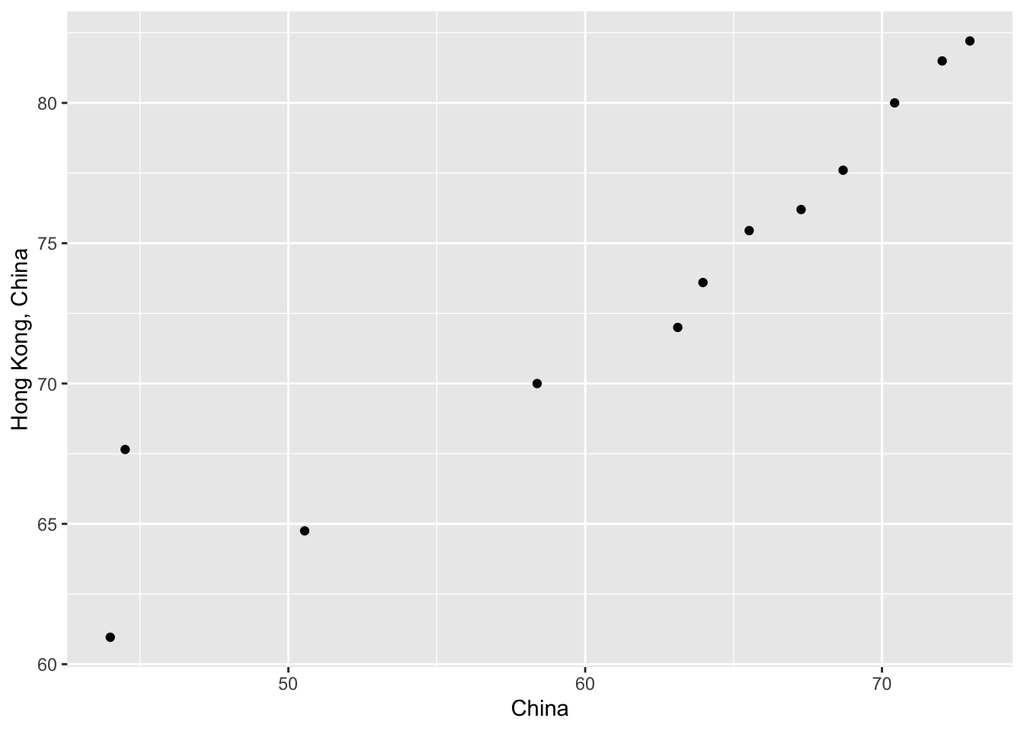

```r
Asia_lifeexp %>%
  select(China, `Hong Kong, China`) %>%
  ggplot()+
  geom_point(aes(China, `Hong Kong, China`))
```

Step 3. Re-lengthen the data. tidyr::pivot_longer().

```r
Asia_lifeexp %>%
  pivot_longer(cols = -year,
               names_to = "country",
               values_to = "LifeExp") %>%
  arrange(country, year)
```

```
## # A tibble: 396 x 3
##     year country     LifeExp
##    <int> <chr>         <dbl>
##  1  1952 Afghanistan    28.8
##  2  1957 Afghanistan    30.3
##  3  1962 Afghanistan    32.0
##  4  1967 Afghanistan    34.0
##  5  1972 Afghanistan    36.1
##  6  1977 Afghanistan    38.4
##  7  1982 Afghanistan    39.9
##  8  1987 Afghanistan    40.8
##  9  1992 Afghanistan    41.7
## 10  1997 Afghanistan    41.8
## # … with 386 more rows
```

# Exercise 2: Multivariate Data Reshaping

Step 1.Make a tibble with one row per year, and columns for life expectancy and GDP per capita (or two other numeric variables) for two or more countries. -> I selected Oceania.

```r
oceania <- gapminder %>%
  filter (continent == 'Oceania') %>%
  pivot_wider(id_cols = c(year, continent),
              names_from  = country,
              names_sep   = "_",
              values_from = c(lifeExp, gdpPercap))
```

Step2. Re-lengthen the data.

```r
oceania %>% pivot_longer(cols = c(-continent, -year),
                    names_to = c(".value", "country"),
                    names_sep = "_")
```

```
## # A tibble: 24 x 5
##     year continent country     lifeExp gdpPercap
##    <int> <fct>     <chr>         <dbl>     <dbl>
##  1  1952 Oceania   Australia      69.1    10040.
##  2  1952 Oceania   New Zealand    69.4    10557.
##  3  1957 Oceania   Australia      70.3    10950.
##  4  1957 Oceania   New Zealand    70.3    12247.
##  5  1962 Oceania   Australia      70.9    12217.
##  6  1962 Oceania   New Zealand    71.2    13176.
##  7  1967 Oceania   Australia      71.1    14526.
##  8  1967 Oceania   New Zealand    71.5    14464.
##  9  1972 Oceania   Australia      71.9    16789.
## 10  1972 Oceania   New Zealand    71.9    16046.
## # … with 14 more rows
```

# Exercise 3: Table Joins

Read in the made-up wedding guestlist and email addresses using the following lines (go ahead and copy-paste these):

```r
guest <- read_csv("https://raw.githubusercontent.com/STAT545-UBC/Classroom/master/data/wedding/attend.csv")
email <- read_csv("https://raw.githubusercontent.com/STAT545-UBC/Classroom/master/data/wedding/emails.csv")

guest
```

```
## # A tibble: 30 x 7
##    party name  meal_wedding meal_brunch attendance_wedd… attendance_brun…
##    <dbl> <chr> <chr>        <chr>       <chr>            <chr>
##  1     1 Somm… PENDING      PENDING     PENDING          PENDING
##  2     1 Phil… vegetarian   Menu C      CONFIRMED        CONFIRMED
##  3     1 Blan… chicken      Menu A      CONFIRMED        CONFIRMED
##  4     1 Emaa… PENDING      PENDING     PENDING          PENDING
##  5     2 Blai… chicken      Menu C      CONFIRMED        CONFIRMED
##  6     2 Nige… <NA>         <NA>        CANCELLED        CANCELLED
##  7     3 Sine… PENDING      PENDING     PENDING          PENDING
##  8     4 Ayra… vegetarian   Menu B      PENDING          PENDING
##  9     5 Atla… PENDING      PENDING     PENDING          PENDING
## 10     5 Denz… fish         Menu B      CONFIRMED        CONFIRMED
## # … with 20 more rows, and 1 more variable: attendance_golf <chr>
```

```r
email
```

```
## # A tibble: 14 x 2
##    guest                                             email
##    <chr>                                             <chr>
##  1 Sommer Medrano, Phillip Medrano, Blanka Medrano,… sommm@gmail.com
##  2 Blair Park, Nigel Webb                            bpark@gmail.com
##  3 Sinead English                                    singlish@hotmail.ca
##  4 Ayra Marks                                        marksa42@gmail.com
##  5 Jolene Welsh, Hayley Booker                       jw1987@hotmail.com
##  6 Amayah Sanford, Erika Foley                       erikaaaaaa@gmail.com
##  7 Ciaron Acosta                                     shining_ciaron@gmail.…
##  8 Diana Stuart                                      doodledianastu@gmail.…
##  9 Daisy-May Caldwell, Martin Caldwell, Violet Cald… caldwellfamily5212@gm…
## 10 Rosanna Bird, Kurtis Frost                        rosy1987b@gmail.com
## 11 Huma Stokes, Samuel Rutledge                      humastokes@gmail.com
## 12 Eddison Collier, Stewart Nicholls                 eddison.collier@gmail…
## 13 Turner Jones                                      tjjones12@hotmail.ca
## 14 Albert Marshall, Vivian Marshall                  themarshallfamily1234…
```

Then, complete the following tasks using the tidyverse (tidyr, dplyr, …). No need to do any pivoting – feel free to leave guest in its current format.

Step 1. For each guest in the guestlist (guest tibble), add a column for email address, which can be found in the email tibble.

```r
email1 <- email %>%
  separate_rows(guest, sep = ',') %>%
  rename(name = guest)
email1
```

```
## # A tibble: 28 x 2
##    name               email
##    <chr>              <chr>
##  1 Sommer Medrano     sommm@gmail.com
##  2 " Phillip Medrano" sommm@gmail.com
##  3 " Blanka Medrano"  sommm@gmail.com
##  4 " Emaan Medrano"   sommm@gmail.com
##  5 Blair Park         bpark@gmail.com
##  6 " Nigel Webb"      bpark@gmail.com
##  7 Sinead English     singlish@hotmail.ca
##  8 Ayra Marks         marksa42@gmail.com
##  9 Jolene Welsh       jw1987@hotmail.com
## 10 " Hayley Booker"   jw1987@hotmail.com
## # … with 18 more rows
```

```r
guest <- guest %>%
  left_join(email1, by = "name")

guest
```

```
## # A tibble: 30 x 8
##    party name  meal_wedding meal_brunch attendance_wedd… attendance_brun…
##    <dbl> <chr> <chr>        <chr>       <chr>            <chr>
##  1     1 Somm… PENDING      PENDING     PENDING          PENDING
##  2     1 Phil… vegetarian   Menu C      CONFIRMED        CONFIRMED
##  3     1 Blan… chicken      Menu A      CONFIRMED        CONFIRMED
##  4     1 Emaa… PENDING      PENDING     PENDING          PENDING
##  5     2 Blai… chicken      Menu C      CONFIRMED        CONFIRMED
##  6     2 Nige… <NA>         <NA>        CANCELLED        CANCELLED
##  7     3 Sine… PENDING      PENDING     PENDING          PENDING
##  8     4 Ayra… vegetarian   Menu B      PENDING          PENDING
##  9     5 Atla… PENDING      PENDING     PENDING          PENDING
## 10     5 Denz… fish         Menu B      CONFIRMED        CONFIRMED
## # … with 20 more rows, and 2 more variables: attendance_golf <chr>,
## #   email <chr>
```

Step 2. Who do we have emails for, yet are not on the guestlist?

```r
email1 %>%
  anti_join(guest, by = "email")
```

```
## # A tibble: 3 x 2
##   name               email
##   <chr>              <chr>
## 1 Turner Jones       tjjones12@hotmail.ca
## 2 Albert Marshall    themarshallfamily1234@gmail.com
## 3 " Vivian Marshall" themarshallfamily1234@gmail.com
```

```r
guest %>%
  semi_join(email1, by = "email")
```

```
## # A tibble: 12 x 8
##    party name  meal_wedding meal_brunch attendance_wedd… attendance_brun…
##    <dbl> <chr> <chr>        <chr>       <chr>            <chr>
##  1     1 Somm… PENDING      PENDING     PENDING          PENDING
##  2     2 Blai… chicken      Menu C      CONFIRMED        CONFIRMED
##  3     3 Sine… PENDING      PENDING     PENDING          PENDING
##  4     4 Ayra… vegetarian   Menu B      PENDING          PENDING
##  5     6 Jole… <NA>         <NA>        CANCELLED        CANCELLED
##  6     7 Amay… <NA>         PENDING     CANCELLED        PENDING
##  7     8 Ciar… PENDING      Menu A      PENDING          PENDING
##  8     9 Dian… vegetarian   Menu C      CONFIRMED        CONFIRMED
##  9    12 Dais… chicken      Menu B      CONFIRMED        CONFIRMED
## 10    13 Rosa… vegetarian   Menu C      CONFIRMED        CONFIRMED
## 11    14 Huma… <NA>         <NA>        CANCELLED        CANCELLED
## 12    15 Eddi… PENDING      PENDING     PENDING          PENDING
## # … with 2 more variables: attendance_golf <chr>, email <chr>
```